# Practical C

Anne Vinkel, adapted from ‘An Introduction to data cleaning with R’ by Edwin de Jonge and Mark van der Loo

Statistical Programming with R

### 1 - a bit on factors

**Define the vector**

```r
v <- factor(c(1,8.2,3,11))
```

**What happens if you apply the function `as.numeric` to `v`? How can you make `v` into a numeric vector?**

```r
as.numeric(v)
```

```
## [1] 1 3 2 4
```

Since `v` is a factor, the visible values in it are actually labels for the underlying factor values - which are nicely ordered consequtive integers. In order to make `v` numeric with the *right* values, use

```r
as.numeric(as.character(v))
```

```
## [1]  1.0  8.2  3.0 11.0
```

### 2 - reading in data with base R and `readxl`

**The file `unnamed.xls` contains comma-separated values of ages and heights for a set of imaginary persons. Read in the data. Make sure to name both variables, and make both numeric. Hint: The `parse_number` function in the `readr` package is nice**

```r
unnamed <- readxl::read_excel("data/unnamed.xls",
                   col_names = c("age", "height"))
unnamed
```

```
## # A tibble: 4 x 2
##     age height
##   <dbl> <chr>
## 1    21 6.0
## 2    42 5.9
## 3    18 5.7*
## 4    21 NA
```

```r
unnamed$height <- readr::parse_number(unnamed$height)
unnamed
```

```
## # A tibble: 4 x 2
##     age height
##   <dbl>  <dbl>
## 1    21    6
## 2    42    5.9
## 3    18    5.7
## 4    21   NA
```

### 3a - data cleaning

**Exercise 3 is about removing inconsistencies from data. The exercise comes in two versions: One using base procedures by “hand”, and one using the editrules package. This first version is less abstract and does not require looking into a new framework. Feel free to skip it and do 3b instead, if it is too simple - or feel free to skip 3b if it’s too involved**

**We will work with the following data - you can find it on the course homepage or paste it into a text file from here:**

```r
age, agegroup, height, status, yearsmarried
21, adult, 6.0, single, -1
2, child, 3, married, 0
18, adult, 5.7, married, 20
221, elderly, 5, widowed, 2
34, child, -7, married, 3
```

```r
people <- read.csv( file = "data/people.txt", stringsAsFactors = F, strip.white = T)
```

**We are going to replace impossible values with `NA`:** * **Age should not be negative and should be less than 150** * **Height should be greater than zero** * **Age should be greater than the number of years married** * **Children cannot be married or widowed** * **People under 18 of age should be coded as children, those between 18 and 64 should be coded as adults, and those over age 65 should be coded as elderly** * **Age should be larger than or equal to yearsmarried + 18**

```r
library(dplyr)
## Age should not be negative and should be less than 150
people <- people %>% mutate( age = ifelse( age < 0, NA, age))
people <- people %>% mutate( age = ifelse( age>=150, NA, age))

##Height should be greater than zero
people <- people %>% mutate( height = ifelse( height <=0, NA, height))
```

So far so good. But the rest of the rules involve some matter of choice: If age and years married are inconsistent, which do we correct, for instance? For a rule, we could say that between age, age group and status, if two of them agree and the third doesn’t, we fix the third.

```r
people <- people %>% mutate( agegroup = ifelse(  agegroup ==  "child" &
                                                 status %in% c("married", "widowed") &
                                                 age >= yearsmarried + 18,
                                                 ifelse(age<=65, "adult", "elderly"),
                                                 agegroup
                                  )) # Here we can actually deduce the value from "age"

people <- people %>% mutate( status = ifelse( agegroup == "child" &
                                              status %in%  c("married", "widowed") &
                                              age < 18,
                                              "single",
                                              status
                                              )) # Here we can also deduce the value

people <- people %>% mutate(age = ifelse( age<18 & agegroup != "child" & status != "single",
                                          NA,
                                          age
                                          )) # Here we set to missing

# When age and yearsmarried do not agree otherwise, we shall believe in age
people <- people %>% mutate( yearsmarried = ifelse( age >= yearsmarried + 18 |
                                                    is.na(age) | is.na(yearsmarried) |
                                                    status == "single"
                                                    , yearsmarried, NA ))

people
```

```
##   age agegroup height  status yearsmarried
## 1  21    adult    6.0  single           -1
## 2   2    child    3.0  single            0
## 3  18    adult    5.7 married           NA
## 4  NA  elderly    5.0 widowed            2
## 5  34    adult     NA married            3
```

### 3b - a walkthrough for the `editrules` package

**This exercise is adapted from an example in De Jonge and van der Loo and walks you through applying functions in the `editrules` package to make a dataset ready for imputation. The `editrules` package allows allows us to define rules which each record of a data set must obey. Editrules can check which rules fail for each record, and find the minimal set of variables to adapt so that all rules can be folowed.**

**We will work with the following data - you can find it on the course homepage or paste it into a text file from here:**

```r
age, agegroup, height, status, yearsmarried
21, adult, 6.0, single, -1
2, child, 3, married, 0
18, adult, 5.7, married, 20
221, elderly, 5, widowed, 2
34, child, -7, married, 3
```

```r
people <- read.csv( file = "data/people.txt", stringsAsFactors = F, strip.white = T)
```

**For a cleaner workflow, the rules that these data must obey are treated as a separate object, that can then be stored and reapplied (instead, say, of treating these rules and checks as lines of code in a syntax file). We define an edit set and confront the data with these rules:**

```r
library(editrules)
E <- editset( c( "age >=0" , "age <= 150" ) )
E
```

```
##
## Edit set:
## num1 : 0 <= age
## num2 : age <= 150
```

```r
violatedEdits( E, people)
```

```
##       edit
## record  num1  num2
##      1 FALSE FALSE
##      2 FALSE FALSE
##      3 FALSE FALSE
##      4 FALSE  TRUE
##      5 FALSE FALSE
```

**A realistic set of edit rules will be rather larger. It may be defined in a text file and read in with `editset`. Try for the rule set in the `peoplerules.txt` file. Also, with a larger rule set, the `summary` and `plot` functions for the `violatedEdits` object become useful.**

```r
E <- editfile("data/peoplerules.txt")
ve <- violatedEdits(E, people)
summary(ve)
```

```
## Edit violations, 5 observations, 0 completely missing (0%):
##
##  editname freq rel
##      cat5    2 40%
##      mix6    2 40%
##      num2    1 20%
##      num3    1 20%
##      num4    1 20%
##      mix8    1 20%
##
## Edit violations per record:
##
##  errors freq rel
##       0    1 20%
##       1    1 20%
##       2    2 40%
##       3    1 20%
```

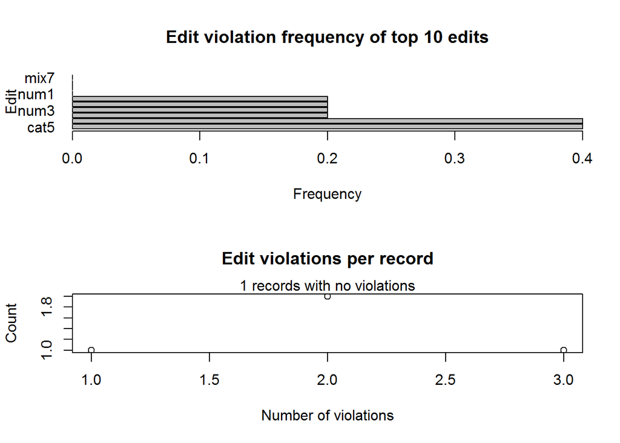

```r
plot(ve)
```

**Obviously, fixing errors requires subject matter expertise, but the `editrules` package does have facilities for finding potential fixes. The logic goes as follows: Fixing a variable so that an error is eliminated may cause new errors. Also, it makes sense to chose the edits necessary to make a record consistent in a way so as to minimise the total number of edits. This is a minimisation problem and can be automated. Further add-ons for the methods allow finer control by adding confidence weights. A branch-and-bound approach instead of the MIP solver used here is more slow but also allows for more control.**

```r
le <- localizeErrors(E, people, method = "mip")
le$adapt
```

```
##     age agegroup height status yearsmarried
## 1 FALSE    FALSE  FALSE  FALSE        FALSE
## 2 FALSE    FALSE  FALSE   TRUE        FALSE
## 3  TRUE    FALSE  FALSE  FALSE        FALSE
## 4  TRUE    FALSE  FALSE  FALSE        FALSE
## 5 FALSE     TRUE   TRUE  FALSE        FALSE
```

**The `le` object contains metadata and a logical array which indicates the minimal set of edits needed to make data follow the rules in `E` (note that `E` is missing at least one rule). The corrections are not part of the `editrules` package.**

### 4 - more on the `editrules` package

**This exercise, again borrowed from de Jonge and van der Loo, follows on the previous but has less hand-holding. If you want, you can do the exercise manually, without using the `editrules` package - as in exercise 3a**

#### 4.1 Reading in and manual checks

**The `dirty_iris` dataset can be found on the course webpage. Read in the data, and make sure that strings are not converted to factors. Replace special values with `NA` and compute the proportion of complete observations.**

```r
dirty.iris <- read.csv( file = "data/dirty_iris.txt",
                        stringsAsFactors = F)
summary(dirty.iris)
```

```
##   Sepal.Length     Sepal.Width      Petal.Length    Petal.Width
##  Min.   : 0.000   Min.   :-3.000   Min.   : 0.00   Min.   :0.1
##  1st Qu.: 5.100   1st Qu.: 2.800   1st Qu.: 1.60   1st Qu.:0.3
##  Median : 5.750   Median : 3.000   Median : 4.50   Median :1.3
##  Mean   : 6.559   Mean   : 3.391   Mean   : 4.45   Mean   :Inf
##  3rd Qu.: 6.400   3rd Qu.: 3.300   3rd Qu.: 5.10   3rd Qu.:1.8
##  Max.   :73.000   Max.   :30.000   Max.   :63.00   Max.   :Inf
##  NA's   :10       NA's   :17       NA's   :19      NA's   :12
##    Species
##  Length:150
##  Class :character
##  Mode  :character
##
##
##
##
```

```r
## There are Inf values in Petal.Width
dirty.iris$Petal.Width[ !is.finite(dirty.iris$Petal.Width) ] <- NA

## The complete.cases function checks each record for missing values
prop.table( table( complete.cases(dirty.iris) ))
```

```
##
##     FALSE      TRUE
## 0.3666667 0.6333333
```

#### 4.2 Validating with rules

**Codify the following rules into an `editfile` object:**

- **Species should be one of the following values: setosa, versicolor or virginica.**
- **All measurements should be positive.**
- **Petal length is at least 2 times petal width.**
- **Sepal length cannot exceed 30 cm.**
- **The sepals of an iris are longer than its petals.**

```r
iris.rules <- editset(
  c(
    "Species %in% c('setosa', 'versicolor', 'virginica')",
    "Sepal.Length > 0",
    "Sepal.Width  > 0",
    "Petal.Length > 0",
    "Petal.Width  > 0",
    "Petal.Length >= 2*Petal.Width",
    "Sepal.Length <=30",
    "Sepal.Length >= Petal.Length"
  )
)
```

**Find out how often each rule is broken. Summarise and plot the object.**

```r
violated.rules.iris <- violatedEdits( iris.rules, dirty.iris)
summary(violated.rules.iris)
```

[output not shown]

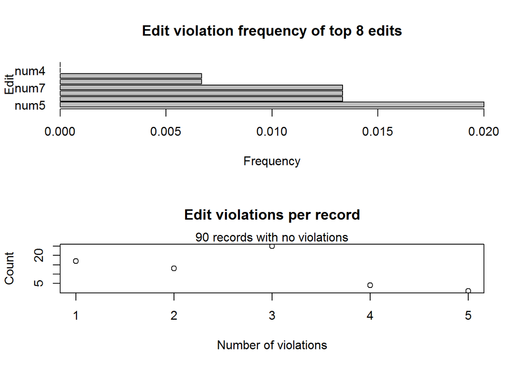

```r
plot(violated.rules.iris)
```

**Use `violatedEdits` to find the observations with too long petals** Which column of the matrix returned by the function corresponds to that rule? We first look at the rules in the rules object

```r
iris.rules
```

```
##
## Data model:
## dat1 : Species %in% c('setosa', 'versicolor', 'virginica')
##
## Edit set:
## num1 : 0 < Sepal.Length
## num2 : 0 < Sepal.Width
## num3 : 0 < Petal.Length
## num4 : 0 < Petal.Width
## num5 : 2*Petal.Width <= Petal.Length
## num6 : Sepal.Length <= 30
## num7 : Petal.Length <= Sepal.Length
```

The rule is “num7”. It’s easier to pick out this rule from `violated.rules.iris` if we make it into a tibble

```r
library(dplyr)
violated.rules.iris %>% as_tibble() %>%
  filter(num7 == T)
```

```
## # A tibble: 2 x 8
##   num1  num2  num3  num4  num5  num6  num7  dat1
##   <lgl> <lgl> <lgl> <lgl> <lgl> <lgl> <lgl> <lgl>
## 1 FALSE FALSE FALSE FALSE FALSE FALSE TRUE  FALSE
## 2 TRUE  NA    FALSE FALSE FALSE FALSE TRUE  FALSE
```

```r
## Find the observations corresponding to this:

## First we find the indices of these observations

indices <- violated.rules.iris %>%
    as_tibble() %>%
    mutate( id = row_number()) %>%
    filter(num7 == T)

dirty.iris[indices$id,]
```

```
##    Sepal.Length Sepal.Width Petal.Length Petal.Width    Species
## 35          6.6         2.9         23.0         1.3 versicolor
## 43          0.0          NA          1.3         0.4     setosa
```

**Use `boxplot` and `boxplot.stats` to find observations with outlier values of sepal length. Set outliers to `NA`**

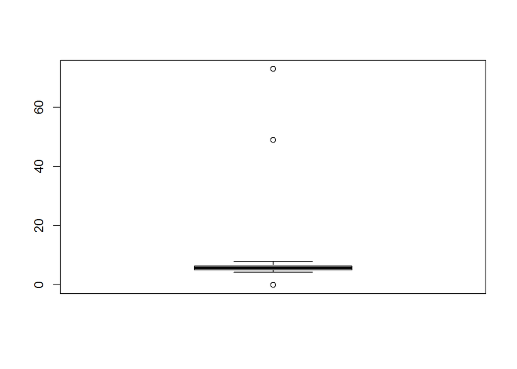

```r
## boxplot does a box plot
boxplot(dirty.iris$Sepal.Length)
```

```r
## boxplot.stats does statistics for the boxplot
bps <- boxplot.stats(dirty.iris$Sepal.Length)
bps
```

```
## $stats
## [1] 4.30 5.10 5.75 6.40 7.90
##
## $n
## [1] 140
##
## $conf
## [1] 5.576405 5.923595
##
## $out
## [1] 73  0 49
```

```r
dirty.iris <- dirty.iris %>%
  mutate( Sepal.Length = if_else(Sepal.Length %in% bps$out, NA_real_, Sepal.Length))
```

#### 4.3 Correcting data

```r
library(deducorrect)

# We make a set of correction rules
iris.cr <- correctionRules(expression(
   if ( is.na(Petal.Length) | Petal.Length <= 0 ) Petal.Length <- NA
))

# We use the correction rules on the data
iris.corrections <- correctWithRules( iris.cr , dirty.iris)

iris.corrections$corrections
```

```
##   row     variable old new
## 1  79 Petal.Length   0  NA
##                                                               how
## 1 if (is.na(Petal.Length) | Petal.Length <= 0) Petal.Length <- NA
```

```r
## It's not very good practise, but we'll replace the data with the corrected data
dirty.iris <- iris.corrections$corrected
```

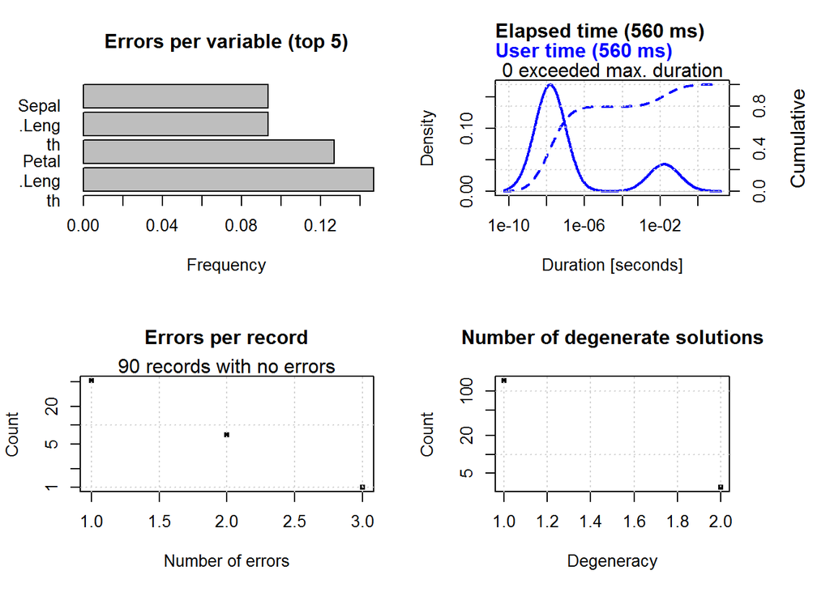

```r
iris.loc.err <- localizeErrors( iris.rules , dirty.iris)
plot(iris.loc.err)
```

```r
# DEGENERATE solutions are those with more than one possible edit. We look at them
table(iris.loc.err$status$degeneracy)
```

```
##
##   1   2
## 147   3
```

```r
dirty.iris[iris.loc.err$status$degeneracy>1,]
```

```
##     Sepal.Length Sepal.Width Petal.Length Petal.Width    Species
## 30            NA         2.8        0.820         1.3 versicolor
## 35           6.6         2.9       23.000         1.3 versicolor
## 106          5.5          NA        0.925         1.0 versicolor
```

```r
iris.loc.err$adapt[iris.loc.err$status$degeneracy>1,]
```

```
##     Sepal.Length Sepal.Width Petal.Length Petal.Width Species
## 30          TRUE       FALSE        FALSE        TRUE   FALSE
## 35          TRUE       FALSE        FALSE       FALSE   FALSE
## 106        FALSE        TRUE         TRUE       FALSE   FALSE
```

```r
# We set all values deemed faulty to NA
dirty.iris[iris.loc.err$adapt] <- NA

summary(violatedEdits( iris.rules, dirty.iris))
```

```
## No violations detected, 151 checks evaluated to NA
```